# Data Profiling Report

### Basic Statistics

#### Raw Counts

| Name | Value |
| --- | --- |
| Rows | 4,428,640 |
| Columns | 27 |
| Discrete columns | 19 |
| Continuous columns | 8 |
| All missing columns | 0 |
| Missing observations | 1,060,793 |
| Complete Rows | 3,874,379 |
| Total observations | 119,573,280 |
| Memory allocation | 710.4 Mb |

#### Percentages

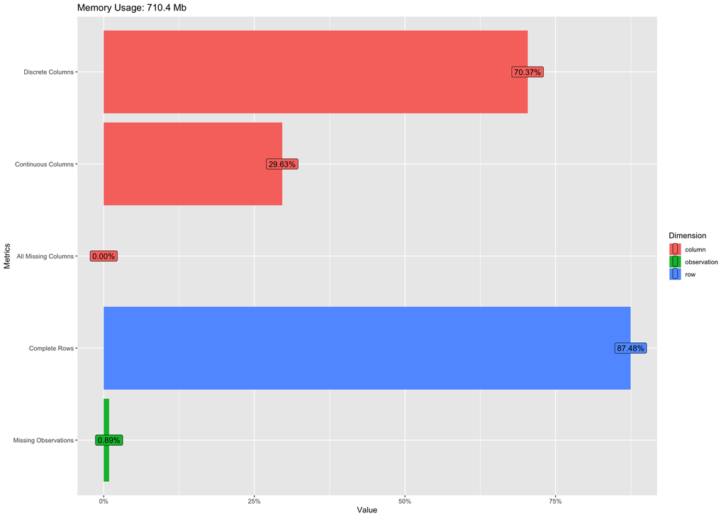

### Data Structure

[interactive chart not shown]

### Missing Data Profile

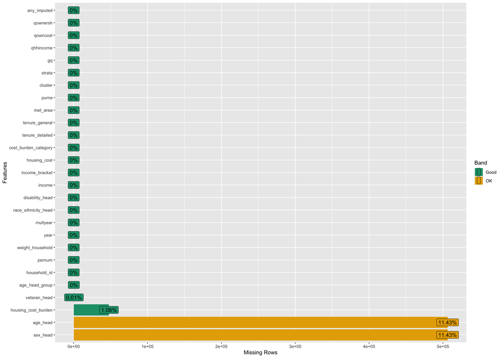

### Univariate Distribution

#### Histogram

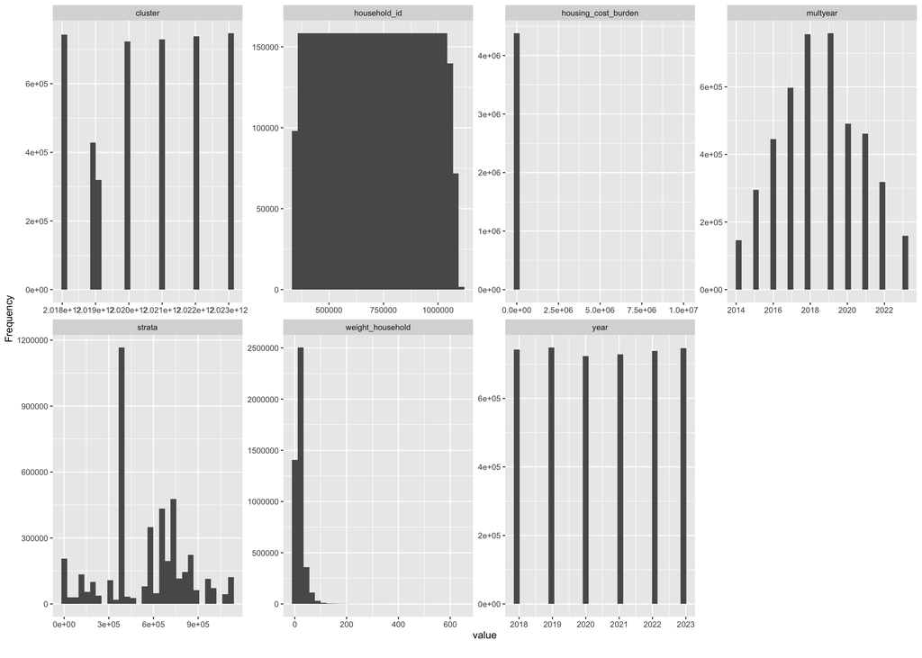

#### Bar Chart (with frequency)

```
## 4 columns ignored with more than 50 categories.
## age_head: 78 categories
## income: 226716 categories
## housing_cost: 62840 categories
## puma: 366 categories
```

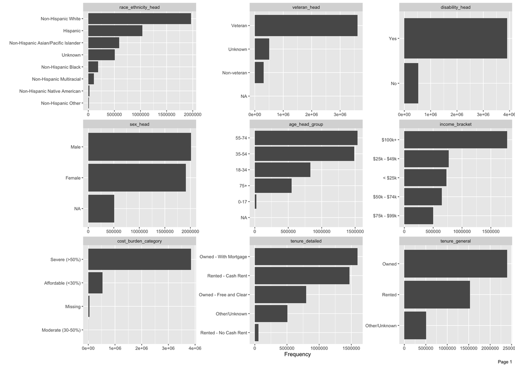

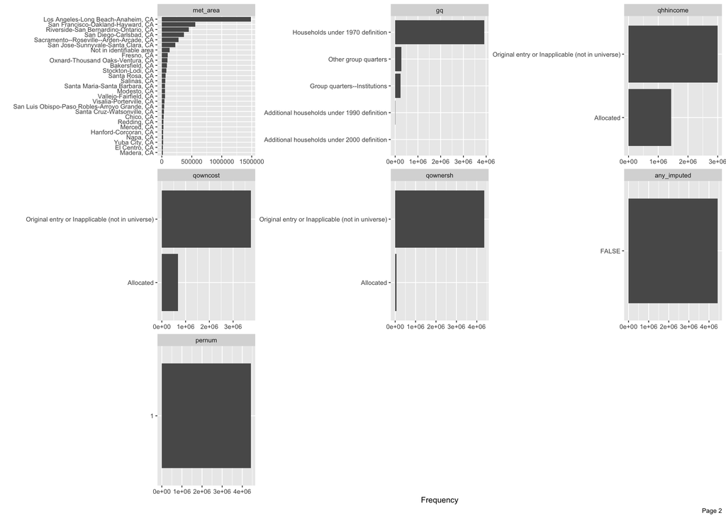

#### QQ Plot

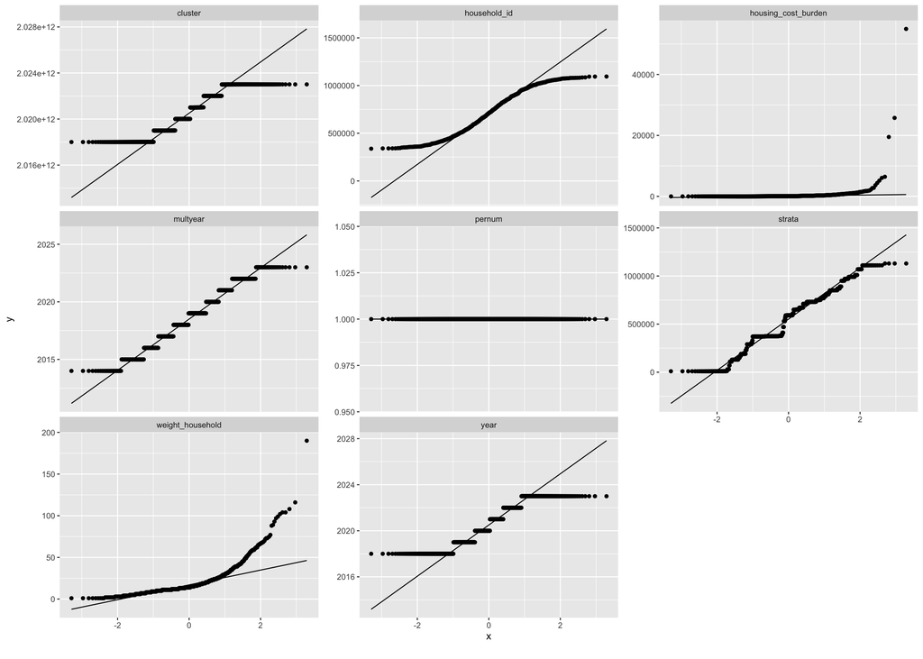